# Analítica Computacional

Sesión #4: Regresión Logística

Autor/a

Afiliación

Jorge I. Vélez, PhD

Universidad del Norte, Barranquilla

Fecha de publicación

6 de abril de 2024

## Introducción

La Regresión Logística (RL) es útil cuando se tiene una variable aleatoria respuesta $Y$ de tipo binario que representa el éxito/fracaso, un producto conforme o no conforme, o si una persona desarrolla o no una enfermedad.

En el modelo de RL hace parte del Modelo Lineal Generalizado (MLG) formulado por John Nelder y Robert Wedderburn en 1972 como una familia de modelos de regresión en los que la naturaleza de la variable respuesta $Y$ puede ser distinta a una distribución Normal. En la práctica, esto se refiere a que la variable respuesta $Y$ no necesariamente debe ser continua o simétrica.

Para más información, puede consultar la Sección [4.2](https://jivelez.github.io/book-adii/glm.html#regresi%C3%B3n-log%C3%ADstica) de [*Modelos de Regresión: Una aproximación práctica con R*](https://jivelez.github.io/book-adii/).

[figure not shown]

Modelos de Regresión: Una aproximación práctica con R. Tomado de [aquí](https://jivelez.github.io/book-adii/).

En el MLG, el interés es predecir una función del *valor esperado* de la respuesta $Y$, es decir, predecimos $g(E[Y])$. Usualmente esta función $g(\cdot)$ se conoce como función de enlace o función `link`. Aunque en el modelo de RL existen diferentes funciones `link`, en la práctica es frecuente utilizar

$$g(x) = \text{logit}(x) = \log\left(\frac{x}{1-x}\right)$$

Puesto que

$$Y =
\begin{cases}
1 \text{ si ocurre el evento de interés} \\
0 \text{ en otro caso}
\end{cases}$$

un *posible* modelo probabilístico para describir $Y$ es *asumir* que

$$Y\sim\text{Bernoulli}(\theta), \quad\quad 0<\theta<1$$

donde $\theta = P(Y=1)$. Es fácil mostrar que $E[Y] = \theta$.

Ahora, si se tienen un conjunto de variables independientes $x_1, x_2, \ldots, x_k$ que podrían eventualmente influenciar $g(E[Y])$, entonces la estructura del modelo de RL está dada por:

$$g(E[Y]) = g(\theta) = \beta_0 + \beta_1x_1 + \beta_2x_2 + \cdots + \beta_kx_k + \epsilon$$
donde $\epsilon$ es el error aleatorio.

Teniendo en cuenta la función de enlace, esta ecuación puede reescribirse como

$$\log\left(\frac{\theta}{1-\theta}\right) = \beta_0 + \beta_1x_1 + \beta_2x_2 + \cdots + \beta_kx_k + \epsilon$$

A partir de una muestra de tamaño $n$, el modelo de RL ajustado es

$$\log\left(\frac{\hat{\theta}}{1-\hat{\theta}}\right) = \hat{\beta}_0 + \hat{\beta}_1x_1 + \hat{\beta}_2x_2 + \cdots +\hat{\beta}_kx_k$$

Finalmente,

$$\hat\theta | _{x_1, x_2, \ldots, x_k} = \frac{1}{1+e^{-\hat{\beta}_0 - \hat{\beta}_1x_1 - \hat{\beta}_2x_2 - \cdots -\hat{\beta}_kx_k}}$$

Por lo tanto, si conocemos las variables $x_1, x_2, \ldots, x_k$, es posible calcular

$$P(Y=1 | x_1, x_2, \ldots, x_k) = \hat\theta | _{x_1, x_2, \ldots, x_k}$$

Observe que, por definición, el modelo de RL permite predecir la probabilidad de que ocurra el evento de interés y no el hecho de que este ocurra. En otras palabras, este modelo de de regresión y **no** de clasificación. Sin embargo, los resultados obtenidos pueden utilizarse *posteriormente* para realizar *clasificación*.

En esta práctica de `R` trabajaremos (1) la sintaxis del modelo de Regresión Logística, (2) cómo estimar e interpretar el modelo y (3) cómo construir la curva ROC y determinar *cutoffs* óptimos.

## Ejemplo 1: Programa de Entrenamiento

## Contexto Analítico

Ensambles S.A. (ESA), una reconocida empresa de manufactura de la ciudad, presenta una fracción defectuosa de 25% en toda su producción y, en promedio, 5 unidades defectuosas por cada lote de 20 unidades. ESA produce 3 productos estrella a una velocidad de 3, 6 y 9 unidades por minuto, 3 turnos de 7 horas por día, 6 días a la semana. En un día típico de operaciones, 17% de las unidades corresponden al pruducto `1`, 37% al producto `2` y 50% al producto `3`. Se sabe que el costo de reproceso por unidad de cada producto asciende a $r_j = \sqrt{j+2}$, mientras el costo por desecho es $d_j = \sqrt{j+4}$, $j=1,2,3$.

Con miras a *mejorar* la situación, ESA desarrolla un programa entrenamiento entre 100 de sus trabajadores. Como parte del programa, se controlan la configuración (variable $x_1$, con niveles `A`, `B` y `C`) de la planta, el turno en el que se realiza el programa (variable $x_2$, con niveles `T1`, `T2` y `T3`), y dos variables numéricas $x_3$ y $x_4$ de las que no se tiene mayor información. Al final del programa se registró si la pieza producida pasaba la inspección (variable respuesta $Y$; `1`: Si, `0`: No) y el número de piezas defectuosas que, desafortunadamente, produjo durante el programa. Por facilidad, se decidió que *todos* los trabajadores fabricarían una pieza del producto `2`.

Los estructura de los datos se muestra a continuación:

```
  y x1 x2 x3 x4
1 1  C T3 16 25
2 1  C T2 19 18
3 0  C T2 15 16
4 0  B T3 15 19
5 0  C T1 13 18
6 1  B T1 13 19
```

Las variables relevantes son

- `y`: si la persona pasa o no el programa de entrenamiento (`1`: Si, `0`: No).
- `x1`: configuración (con niveles `A`, `B` y `C`)
- `x2`: turno de trabajo (cn niveles `T1`, `T2` y `T3`)
- `x3`: parámetro 1 de la máquina
- `x4`: parámetro 2 de la máquina

Así por ejemplo, la persona #5 **no pasa** el programa.

### Análisis Exploratorio

```r
## EDA with skimr
skim(d)
```

Data summary

| Name | d |
| --- | --- |
| Number of rows | 100 |
| Number of columns | 5 |
| _______________________ |  |
| Column type frequency: |  |
| character | 2 |
| numeric | 3 |
| ________________________ |  |
| Group variables | None |

**Variable type: character**

| skim_variable | n_missing | complete_rate | min | max | empty | n_unique | whitespace |
| --- | --- | --- | --- | --- | --- | --- | --- |
| x1 | 0 | 1 | 1 | 1 | 0 | 3 | 0 |
| x2 | 0 | 1 | 2 | 2 | 0 | 3 | 0 |

**Variable type: numeric**

| skim_variable | n_missing | complete_rate | mean | sd | p0 | p25 | p50 | p75 | p100 | hist |
| --- | --- | --- | --- | --- | --- | --- | --- | --- | --- | --- |
| y | 0 | 1 | 0.43 | 0.50 | 0 | 0 | 0 | 1 | 1 | ▇▁▁▁▆ |
| x3 | 0 | 1 | 14.21 | 3.00 | 10 | 11 | 14 | 17 | 19 | ▇▆▅▇▆ |
| x4 | 0 | 1 | 20.07 | 4.62 | 12 | 17 | 20 | 24 | 35 | ▅▇▅▂▁ |

En la base de datos, la distribución de `y` es

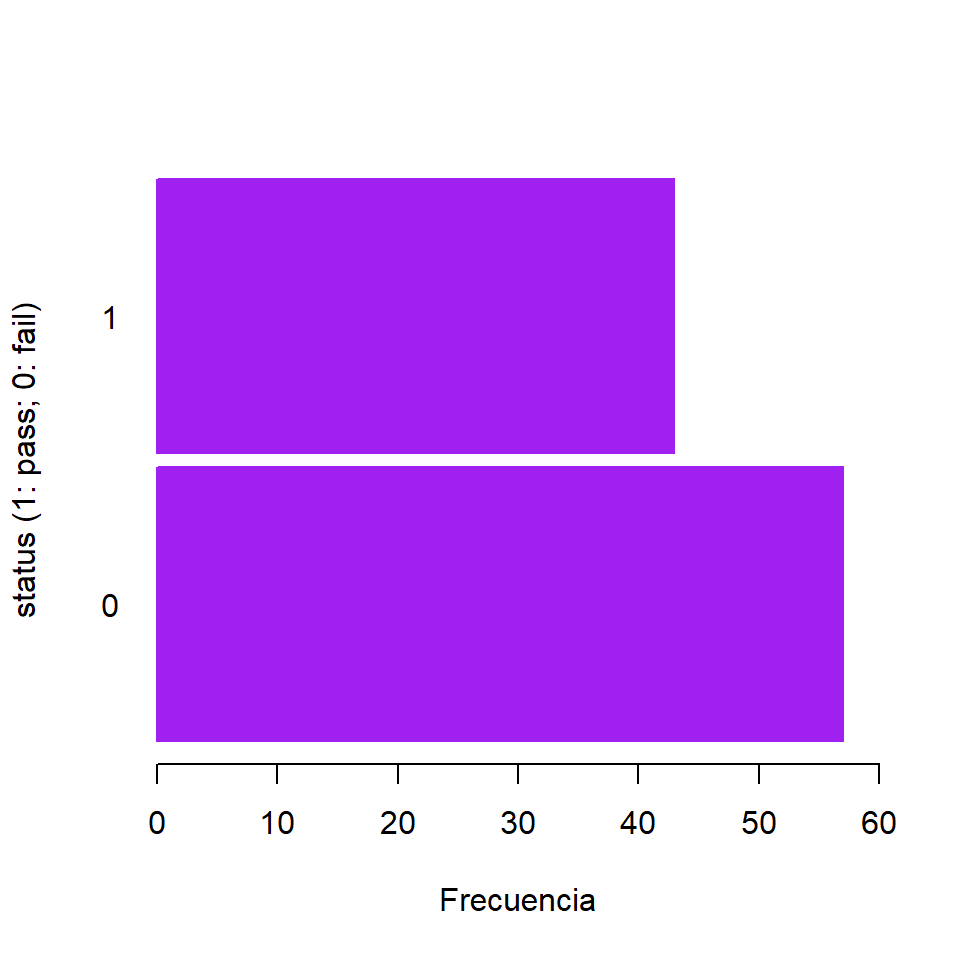

```r
barplot(with(d, table(y)), horiz = TRUE,
        las = 1, space = 0.05,
        xlab = 'Frecuencia',
        ylab = 'status (1: pass; 0: fail)',
        col = 'purple', border = 'purple',
        xlim = c(0, 60))
```

Veamos qué ocurre con las demás variables:

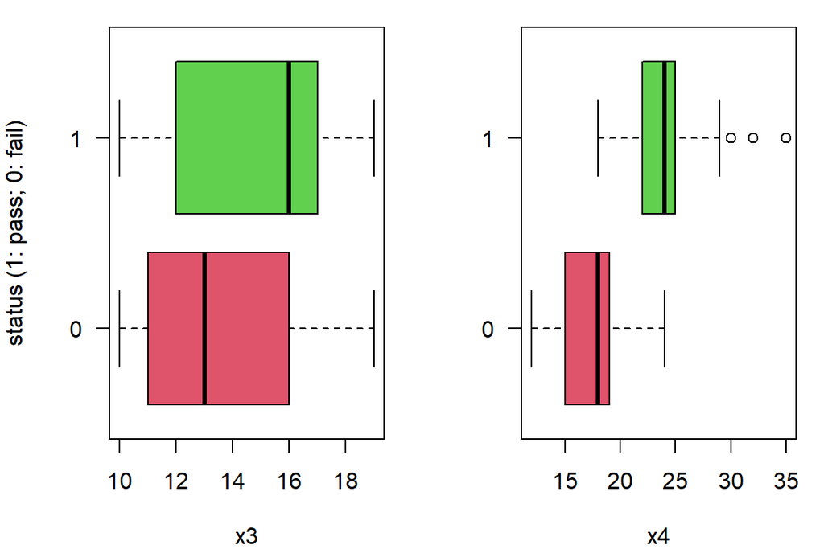

```r
par(mfrow = c(1, 2), mar = c(4, 4, 1, 1))
boxplot(x3 ~ y, data = d, las = 1,
        ylab = 'status (1: pass; 0: fail)',
        col = c(2, 3), horizontal = TRUE)
boxplot(x4 ~ y, data = d, las = 1,
        ylab = '',
        col = c(2, 3), horizontal = TRUE)
```

### Modelo de Regresión Logística

El modelo ajustado puede obtenerse haciendo:

```r
## full logistic regression model
fit <- glm(y ~ ., data = d, family = binomial)
summary(fit)
```

```
Call:
glm(formula = y ~ ., family = binomial, data = d)

Deviance Residuals:
     Min        1Q    Median        3Q       Max
-2.29037  -0.28372  -0.03482   0.09543   2.52701

Coefficients:
            Estimate Std. Error z value Pr(>|z|)
(Intercept) -26.7486     6.2308  -4.293 1.76e-05 ***
x1B           1.7329     1.1183   1.550    0.121
x1C           2.0310     1.0315   1.969    0.049 *
x2T2         -0.8699     0.9744  -0.893    0.372
x2T3         -1.2353     1.3222  -0.934    0.350
x3            0.2928     0.1475   1.986    0.047 *
x4            1.0827     0.2714   3.989 6.64e-05 ***
---
Signif. codes:  0 '***' 0.001 '**' 0.01 '*' 0.05 '.' 0.1 ' ' 1

(Dispersion parameter for binomial family taken to be 1)

    Null deviance: 136.663  on 99  degrees of freedom
Residual deviance:  41.906  on 93  degrees of freedom
AIC: 55.906

Number of Fisher Scoring iterations: 7
```

Veamos si el modelo mejora cuando no incluimos `x2`:

```r
## reduced model
fit_reduced <- glm(y ~ x1 + x3 + x4, data = d, family = binomial)
summary(fit_reduced)
```

```
Call:
glm(formula = y ~ x1 + x3 + x4, family = binomial, data = d)

Deviance Residuals:
     Min        1Q    Median        3Q       Max
-2.33831  -0.35166  -0.03475   0.15138   2.36117

Coefficients:
            Estimate Std. Error z value Pr(>|z|)
(Intercept) -25.4478     5.5904  -4.552 5.31e-06 ***
x1B           1.4260     1.0285   1.387   0.1656
x1C           2.0075     0.9719   2.066   0.0389 *
x3            0.2872     0.1330   2.159   0.0309 *
x4            0.9912     0.2259   4.388 1.14e-05 ***
---
Signif. codes:  0 '***' 0.001 '**' 0.01 '*' 0.05 '.' 0.1 ' ' 1

(Dispersion parameter for binomial family taken to be 1)

    Null deviance: 136.663  on 99  degrees of freedom
Residual deviance:  43.174  on 95  degrees of freedom
AIC: 53.174

Number of Fisher Scoring iterations: 7
```

Observe que el AIC de `fit_reduced` es 53.174 vs. 55.906 de `fit`. Por lo tanto, no incluir `x2` *mejora* el modelo.

Veamos si esta mejora es *estadísticamente significativa*. Para esto usamos la prueba *Likelihood Ratio Test* ([LRT](https://en.wikipedia.org/wiki/Likelihood-ratio_test#:~:text=In%20statistics%2C%20the%20likelihood%2Dratio,the%20ratio%20of%20their%20likelihoods.)):

```r
## models are the same?
lrtest(fit, fit_reduced)
```

```
Likelihood ratio test

Model 1: y ~ x1 + x2 + x3 + x4
Model 2: y ~ x1 + x3 + x4
  #Df  LogLik Df  Chisq Pr(>Chisq)
1   7 -20.953
2   5 -21.587 -2 1.2679     0.5305
```

En este caso, al comparar los modelos `fit` y `fit_reduced` obtenemos un valor $p$ de 0.5305 en la prueba LRT. Esto implica que, estadísticamente, estos modelos *competitivos* son similares. De acuerdo con la formulación, es *preferible* usar `fit_reduced`.

La ecuación del modelo reajustado es

$$\text{logit}(\hat{\theta}) = -25.45 + 1.43x_{1\text{B}} + 2x_{1\text{C}} + 0.29 x_3 + 0.991x_4$$

donde $x_{1\text{B}}$ y $x_{1\text{C}}$ son variables indicadoras.

A partir del objeto `fit_reduced` podemos calcular el *odds ratio* (OR) asociado a cada variable predictora haciendo:

```r
# calculo del OR
exp(coefficients(fit_reduced))[-1]
```

```
     x1B      x1C       x3       x4
4.162165 7.444481 1.332718 2.694376
```

Por lo tanto,

$$\widehat{\text{OR}} = e^{\hat{\beta_1}} = e^{1.43} = 4.16.$$

Los intervalos de confianza (IC) del 95% para los coeficientes del modelo pueden obtenerse haciendo

```r
# calculo del intervalos de confianza para los coeficientes
confint.default(fit_reduced)[-1, ]
```

```
          2.5 %    97.5 %
x1B -0.58976684 3.4418377
x1C  0.10264770 3.9122981
x3   0.02644715 0.5479934
x4   0.54847774 1.4338556
```

Similarmente, los IC del 95% para el OR puede obtenerse haciendo

```r
# calculo del intervalos de confianza para el OR
exp(confint.default(fit_reduced))[-1,]
```

```
        2.5 %    97.5 %
x1B 0.5544565 31.244322
x1C 1.1081010 50.013757
x3  1.0268000  1.729779
x4  1.7306166  4.194842
```

Ahora, a partir del modelo ajustado, las probabilidades estimadas pueden obtenerse como:

```r
## fitted probabilities
thetahat <- fitted(fit_reduced)
thetahat[1:10]
```

```
          1           2           3           4           5           6
0.997360179 0.464533416 0.036497918 0.292917396 0.134071794 0.189126282
          7           8           9          10
0.998645736 0.020739514 0.825347773 0.008709785
```

### Bondad de ajuste

Para verificar que el modelo de Regresión Logística tiene *buen* ajuste, podemos utilizar, por ejemplo, **la prueba de bondad de ajuste de Hosmer & Lemeshow**, el *pseudo* $R^2$ y la curva ROC.

**Hosmer & Lemeshow**

Para más detalles sobre la prueba de Hosmer & Lemeshow ver [aquí](https://thestatsgeek.com/2014/02/16/the-hosmer-lemeshow-goodness-of-fit-test-for-logistic-regression/). En esta prueba, debe decidirse el parámetro $g$. Teóricamente, $g > p+1$, donde $p$ es el número de predictores. En nuestro caso, $p=4$ y, por lo tanto, $g>5$. Por simplicidad, seleccionaremos $g=6$. La prueba se encuentra implementada en la función `hoslem.test` del paquete `ResourceSelection`.

```r
## hosmer & lemeshow GoF test
## usando g grupos
g <- 6

## valor p de la prueba de H & L
hl <- hoslem.test(fit_reduced$y, fitted(fit_reduced), g = g)
hl$p.value
```

```
[1] 0.8750864
```

Basados en la prueba de bondad de ajuste de Hosmer & Lemeshow, podemos decir que el modelo de Regresión Logística ajustado *ajusta* bien puesto que el valor $p$ de la prueba es $>0.05$.

*pseudo*$R^2$

Uno de los *pseudo* $R^2$ más utilizados es el $R^2_{\text{McFadden}}$. De acuerdo con el artículo original, valores de $R^2_{\text{McFadden}}$ entre 0.2 y 0.4 sugieren un **excelente ajuste** del modelo de Regresión Logística. Por otro lado, valores cercanos a 0 indican que el modelo no tiene ningún poder predictivo. Para más detalles, ver [esta](https://stats.stackexchange.com/questions/82105/mcfaddens-pseudo-r2-interpretation) discusión en `stackexchange`.

Para estimar el $R^2_\text{pseudo}$ en `R` utilizamos la función `pR2()` del paquete `pscl`:

```r
## pseudo R^2 para Regresión Logística
pR2(fit_reduced)[4]
```

```
fitting null model for pseudo-r2
```

```
 McFadden
0.6840867
```

**Curva ROC**

Ahora calculemos el AUC utilizando las facilidades ofrecidas por el paquete `pROC`:

```r
## calculo del AUC
## ver http://web.expasy.org/pROC/ y ?roc para mas detalles
(ROC <- roc(y ~ thetahat, data = d))
```

```
Call:
roc.formula(formula = y ~ thetahat, data = d)

Data: thetahat in 57 controls (y 0) < 43 cases (y 1).
Area under the curve: 0.9692
```

A partir de este resultado podemos concluir que el modelo es *bueno* para diferenciar piezas conformes de aquellas no conformes en este proceso de ensamble. En particular, el AUC es 0.969 $>0.7$.

Finalmente, la curva ROC puede obtenese haciendo

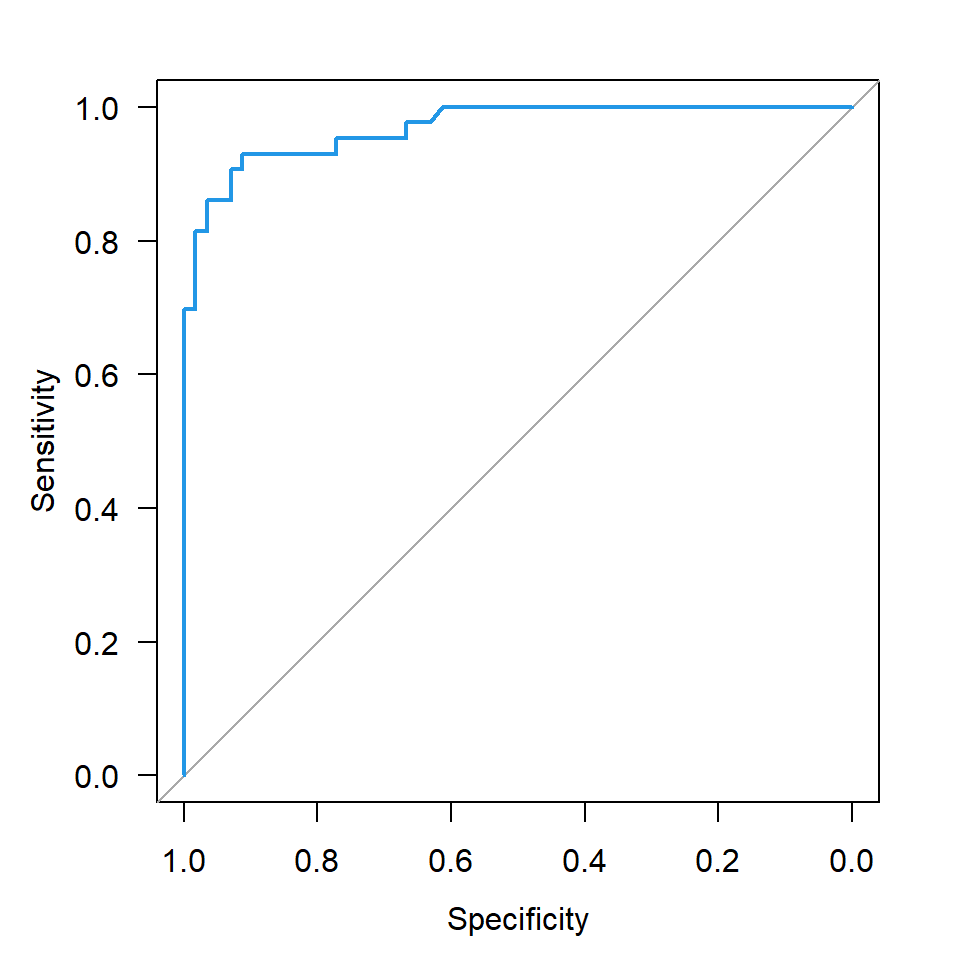

```r
## gráfico de la curva ROC
plot(ROC, las = 1, col = 4)
```

### Predicción

Utilizando el modelo, podríamos entonces estimar la probabilidad de que la persona pase el programa cuando $\mathbf{x}_0 =($ `C` $,$ `T1` $,14, 21)$ haciendo:

```r
## thetahat
x0 <- data.frame(x1 = 'C',
                 x3 = 14,
                 x4 = 21)
theta_hat <- predict(fit_reduced,
                     newdata = x0,
                     type = 'response',
                     se.fit = TRUE)
theta_hat
```

```
$fit
       1
0.801436

$se.fit
        1
0.1179116

$residual.scale
[1] 1
```

$$0.8014\pm 1.96\times 0.118 = (0.57, 1)$$

### Definición del *cutoff*

Para construir la matriz de confusión y varias medidas de desempeño para 1000 *cutoffs* posibles y graficamos los resultados.

Inicialmente cargamos a la sesión de trabajo un conjunto de funciones:

```r
## load functions
source('https://www.dropbox.com/s/xclvdugfbrf5ryn/logistic-functions.R?dl=1')
```

```
Esta es una colección de funciones creadas
por el profesor Jorge Vélez, PhD <https://jorgeivanvelez.netlify.app/>
para el ajuste y validación de modelos de Clasificación Binaria

En caso de presentar algún inconveniente, por favor
repórtelo a <jvelezv@uninorte.edu.co>

Última modificación:  Abril 10, 2024
```

Ahora definomos los *cutoffs* y determinamos, para cada uno, las medidas de desempeño:

```r
##  1000 cutoffs
cutoff <- seq(.1, .9, length = 1000)

##  calculations
res <- bycutoff2(fit_reduced, real = d$y, cutoff)
res <- data.frame(cutoff = cutoff, res)

## first 4 rows
head(res, 4)
```

```
     cutoff  a  b c  d sensitivity specificity       ppv      npv       fdr
1 0.1000000 42 19 1 38   0.9767442   0.6666667 0.6885246 0.974359 0.3114754
2 0.1008008 42 19 1 38   0.9767442   0.6666667 0.6885246 0.974359 0.3114754
3 0.1016016 42 19 1 38   0.9767442   0.6666667 0.6885246 0.974359 0.3114754
4 0.1024024 42 19 1 38   0.9767442   0.6666667 0.6885246 0.974359 0.3114754
        fpr class_rate    lift     delta
1 0.3333333        0.8 1.60122 0.3341436
2 0.3333333        0.8 1.60122 0.3341436
3 0.3333333        0.8 1.60122 0.3341436
4 0.3333333        0.8 1.60122 0.3341436
```

Finalmente graficamos los resultados:

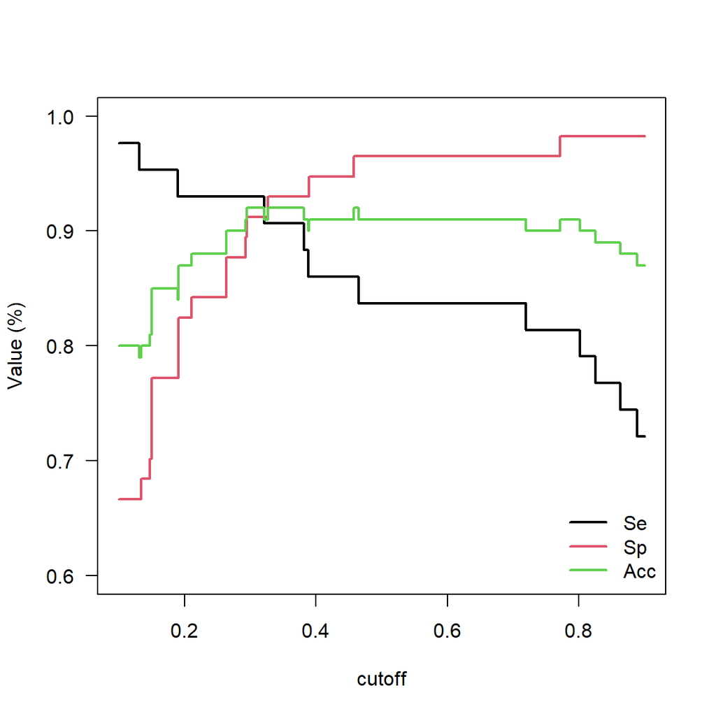

```r
##  gráfico
with(res, matplot(cutoff, cbind(sensitivity, specificity, class_rate),
                  type = 'l', las = 1, ylim = c(0.6, 1), lwd = 2,
                  lty = 1, ylab = 'Value (%)'))
legend('bottomright', c('Se', 'Sp', 'Acc'), lty = 1, col = 1:3, bty = 'n', lwd = 2)
```

A continuación determinamos diferentes *cutoffs* para tres criterios diferentes:

1. Usando $S_e \approx S_p$

```r
res[which.min(abs(res$sensitivity - res$specificity)), ]
```

```
      cutoff  a b c  d sensitivity specificity       ppv       npv       fdr
277 0.321021 39 5 4 52   0.9069767   0.9122807 0.8863636 0.9285714 0.1136364
          fpr class_rate     lift     delta
277 0.0877193       0.91 2.061311 0.1278593
```

2. Maximizando la tasa de clasificación correcta:

```r
res[which.max(res$class_rate), ]
```

```
       cutoff  a b c  d sensitivity specificity       ppv       npv       fdr
244 0.2945946 40 5 3 52   0.9302326   0.9122807 0.8888889 0.9454545 0.1111111
          fpr class_rate     lift     delta
244 0.0877193       0.92 2.067183 0.1120811
```

3. Maximizando el *lift*:

```r
res[which.max(res$lift), ]
```

```
       cutoff  a b c  d sensitivity specificity       ppv   npv        fdr
839 0.7710711 35 1 8 56   0.8139535   0.9824561 0.9722222 0.875 0.02777778
           fpr class_rate     lift     delta
839 0.01754386       0.91 2.260982 0.1868719
```

## Ejemplo 2: una matriz de confusión

En algunas aplicaciones sólo tenemos la matriz de confusión y queremos calcular las medidas de desempeño para el modelo de Regresión Logística:

```r
## matriz de confusion
confusion <- matrix(c(160, 32,
                       20, 246), ncol = 2, byrow = TRUE)
colnames(confusion) <- rownames(confusion) <- c('Yes', 'No')
confusion
```

```
    Yes  No
Yes 160  32
No   20 246
```

La prueba de asociación $\chi^2$ produce

```r
## chi^2
chisq.test(confusion)
```

```
    Pearson's Chi-squared test with Yates' continuity correction

data:  confusion
X-squared = 265.51, df = 1, p-value < 2.2e-16
```

lo cual confirma que *existe* una asociación entre la realidad observada a través de los datos y los resultados predichos por el modelo de Regresión Logística.

A partir de la matriz de confusión podemos calcular varias medias de desempeño:

```r
## performance measures
measures(confusion)
```

```
sensitivity specificity         ppv         npv         fdr         fpr
  0.8888889   0.8848921   0.8333333   0.9248120   0.1666667   0.1151079
 class_rate        lift       delta
  0.8864629   2.1203704   0.1599860
```

Finalmente, la curva ROC obtenerse y graficarse haciendo:

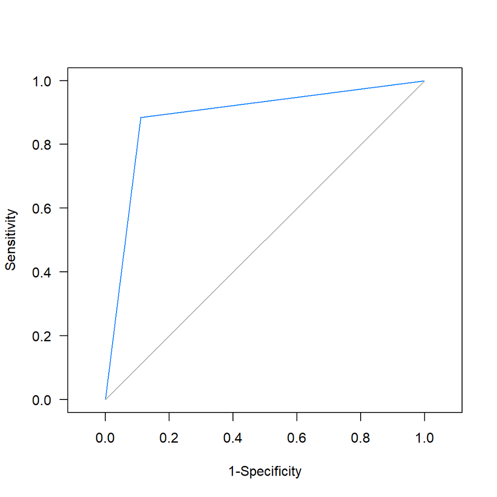

```
$auc
[1] 0.8868905

$original.table
    Non-diseased Diseased
Yes          160       32
No            20      246

$diagnostic.table
      1-Specificity Sensitivity
          1.0000000   1.0000000
> Yes     0.1111111   0.8848921
> No      0.0000000   0.0000000
```

```r
## ahora calculamos la curva ROC a partir de la matriz de confusión
(ROC <- rft(confusion, las = 1))
```

El AUC resultante para esta curva es 0.887. Esto indica que el modelo de Regresión Logística es bueno para disciminar entre personas que potencialmente comprarían el producto de aquellas que definitivamente no lo harían.

## Homework

**Fecha de entrega:** Abril 19, 2024.

Cree usted que la configuración de la planta y el turno en el que se fabriquen las piezas son relevantes para que una persona pase el programa? En qué condiciones recomienda que se desarrolle la prueba del programa? Qué puede decir de $x_3$ y $x_4$? Cuál de las variables tiene *mayor importancia* en el modelo? Qué acciones implementaría para garantizar la *uniformidad* de la producción independiente de la configuración de la planta? Justifique ampliamente su respuesta.

## Referencias

Para más información sobre el modelo de Regresión Logística se sugiere consultar la [Sección 4.2](https://jivelez.github.io/book-adii/glm.html#regresi%C3%B3n-log%C3%ADstica) del texto [*Modelos de Regresión: Una aproximación práctica con R*](https://jivelez.github.io/book-adii/).